# ECON 395: Zillow Part 1

Brianna Penkala & Kai Hoeger

2025-01-31

## 1. Introduction

*Data Structure:* The Zillow data provided is structured in panel form, providing observations about multiple entities over multiple time periods. An observation in this dataset is a region of the country on the last day of each month in a specific year from August 2018 to April 2023 (i.e. Akron, Ohio on August 31, 2018).

*Research Question:* How do the seasons affect housing prices in the U.S.?

*Outcome Variable:* The median sales price of houses in the U.S. during the various seasons.

*Independent Variables:* As the selling price of a house can be affected by a variety of outside factors other than season, we consider the mean days pending, the median price cut, the number of new listings in the month, the median list price, and the Zillow home value index as additional independent variables to account for. The mean days pending reflects the average number of days pending until a house was sold. A longer pending period suggests more negotiations, possibly leading to the deal falling through, affecting the ultimate sale price. The median price cut refers to the median percentage cut taken on the list price of houses in a particular month. We factor in this variable, as taking a price cut will obviously have implications on the selling price of houses. The number of new listings in the month refers to how many houses were put on the market that month, a factor that would increase competition, and, therefore, influence selling price. We also consider the median list price as, again, this variable would have huge implications on the selling price. The Zillow Home Value Index provides a measure of the “typical home value and market changes across a given region and housing type.” Home value is yet another factor that would affect how much a house is sold for, so it is another important variable to consider.

*Hypothesis:* We hypothesize that the season with the lowest house prices is the fall. This may be because the weather is getting cold and the houses will have less curb appeal due to the changing seasons.

## 2. Summary/Descriptive Statistics

|  | Fall (N=1410) | Spring (N=1316) | Summer (N=1222) | Winter (N=1410) | Overall (N=5358) |
| --- | --- | --- | --- | --- | --- |
| Median sales price ($) |  |  |  |  |  |
| Min | 126000 | 124000 | 125000 | 121000 | 121000 |
| Max | 1360000 | 1470000 | 1450000 | 1370000 | 1470000 |
| Median | 265000 | 273000 | 266000 | 271000 | 268000 |
| N | 1410 | 1316 | 1222 | 1410 | 5358 |
| Mean days pending |  |  |  |  |  |
| Min | 11.0 | 8.00 | 9.00 | 14.0 | 8.00 |
| Max | 132 | 131 | 129 | 130 | 132 |
| Median | 35.0 | 35.0 | 29.0 | 45.0 | 36.0 |
| N | 1387 | 1303 | 1206 | 1390 | 5286 |
| Median % cut |  |  |  |  |  |
| Min | 0.0149 | 0.0150 | 0.0146 | 0.0140 | 0.0140 |
| Max | 0.0533 | 0.0604 | 0.0564 | 0.0593 | 0.0604 |
| Median | 0.0288 | 0.0296 | 0.0298 | 0.0286 | 0.0292 |
| N | 1410 | 1284 | 1201 | 1403 | 5298 |
| New listings in month |  |  |  |  |  |
| Min | 378 | 334 | 332 | 223 | 223 |
| Max | 485000 | 501000 | 518000 | 325000 | 518000 |
| Median | 1630 | 1570 | 1870 | 1140 | 1580 |
| N | 1410 | 1316 | 1222 | 1410 | 5358 |
| Median list price ($) |  |  |  |  |  |
| Min | 132000 | 150000 | 158000 | 95000 | 95000 |
| Max | 1360000 | 1440000 | 1430000 | 1350000 | 1440000 |
| Median | 300000 | 302000 | 308000 | 295000 | 300000 |
| N | 1410 | 1314 | 1219 | 1410 | 5353 |
| Zillow home value index |  |  |  |  |  |
| Min | 108000 | 109000 | 108000 | 109000 | 108000 |
| Max | 1520000 | 1590000 | 1590000 | 1510000 | 1590000 |
| Median | 272000 | 285000 | 276000 | 279000 | 278000 |
| N | 1408 | 1316 | 1222 | 1410 | 5356 |

## 3. Correlation Matrices

[figure not shown]

## 4. Outliers

*Methodology:* In order to identify outliers in our data, we started by creating boxplots of each of our identified variables by season. We decided to split our data seasonally as this is our causal variable of interest and it is necessary to determine if any of our groupings are particularly skewed and would therefore bias our results.

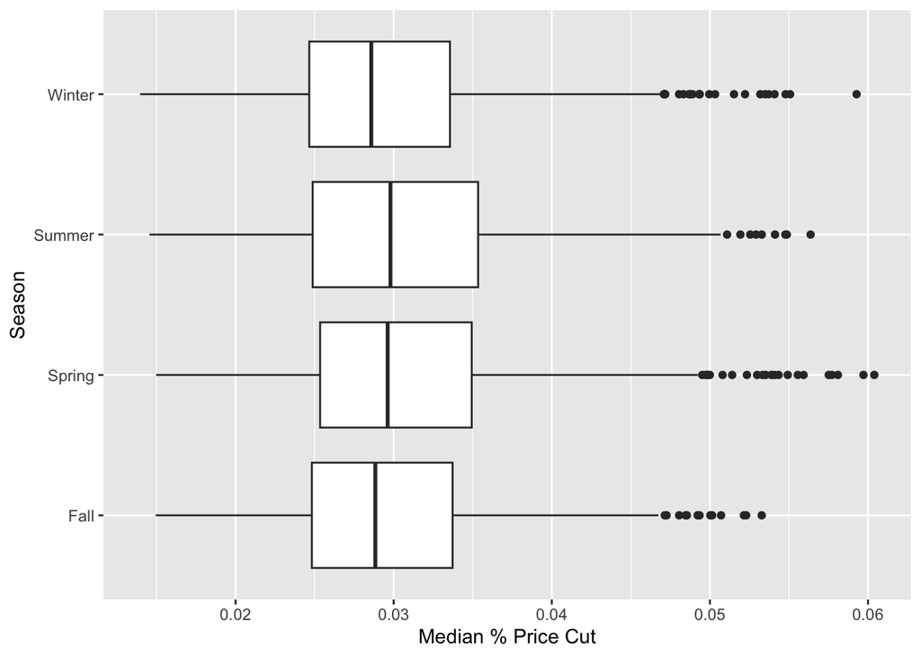

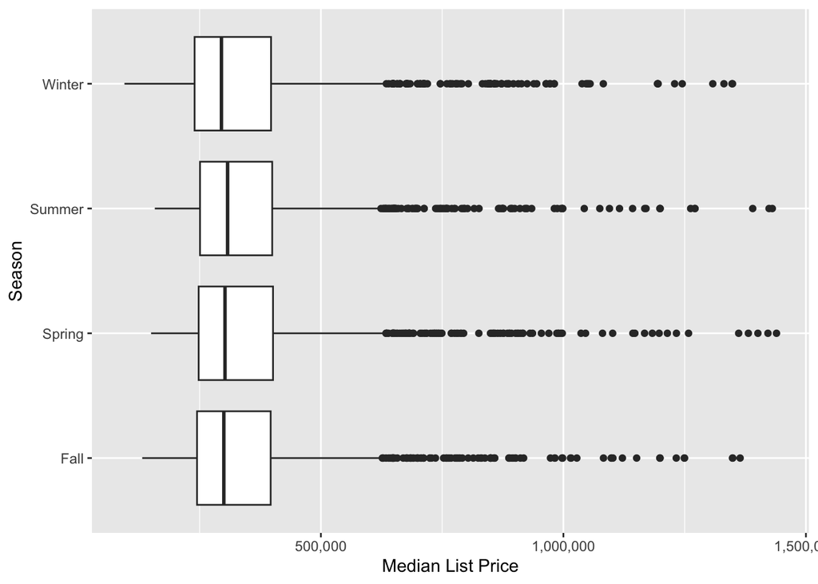

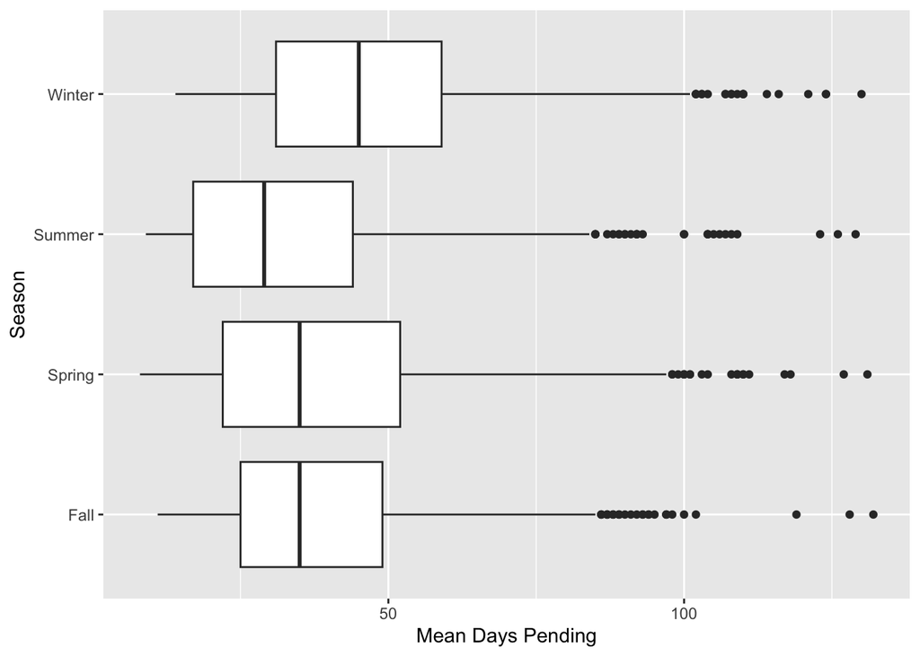

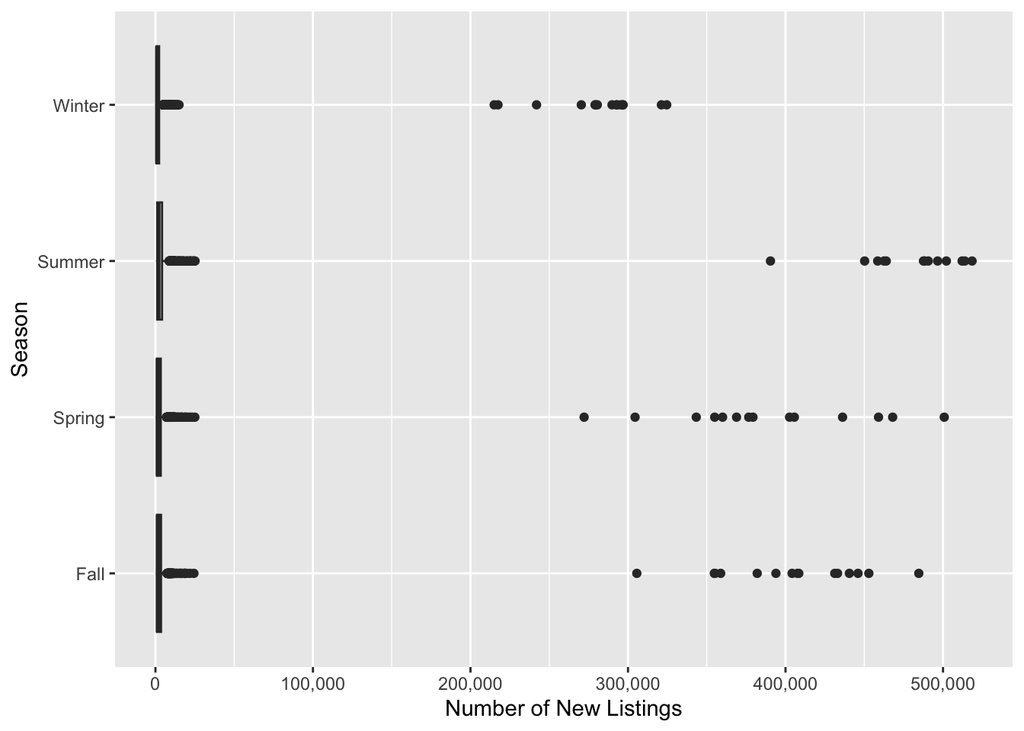

[figure not shown]

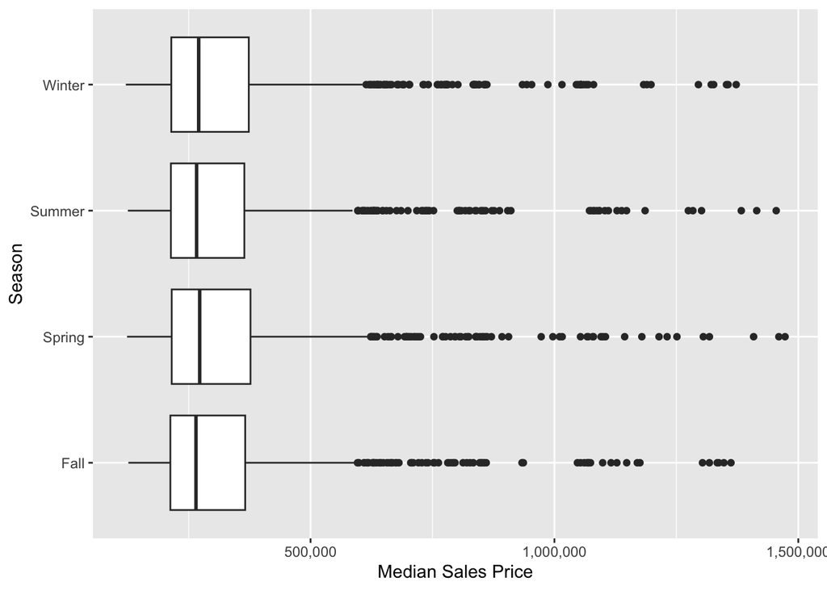

*Determination:* As displayed in our graphs, each of the independent variables we identified have numerous outliers. Looking at the tables listing the number of outliers for each season and variable reveals that the outlier count is fairly consistent across the seasons for each of the variables with the exception of increased outliers for the number of new listings in winter and decreased outliers for the price cut taken in summer. All of the outliers that we identified exceeded the upper bound (as opposed to being beneath the lower bound).

**Outlier Totals**

| Median Sales Price | Price Cut | List Price | Days Pending | Number of New Listings | ZHVI |
| --- | --- | --- | --- | --- | --- |
| 79 | 24 | 96 | 20 | 150 | 84 |
| 72 | 22 | 100 | 21 | 134 | 75 |
| 79 | 9 | 99 | 24 | 120 | 74 |
| 83 | 15 | 100 | 30 | 134 | 86 |

*Analysis:* There are a substantial number of outliers in our data, but because the number of outliers are generally evenly distributed across the four seasons throughout each of our explanatory variables, leaving the outliers in our data should not result in substantial bias. Furthermore, our graphs highlight that the ranges of outliers across the seasons for each variable are comparable, providing further evidence that the removal of outliers is not necessary.

## 5. Data Visualization

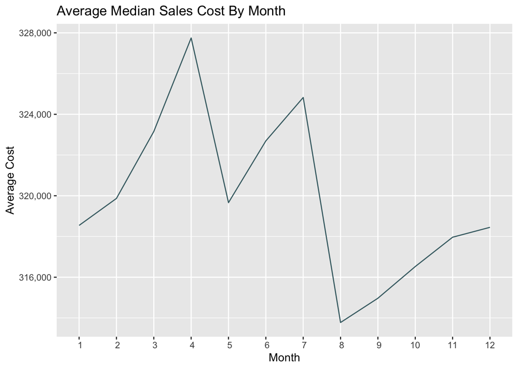

*Line Chart Analysis:* The chart above highlights the movement of selling price across each of the twelve months of the year. From this visualization, more specific information about the average median selling price of houses can be gleaned. It is interesting to note that the average median sales price plummets from April to May and from July to August. Despite these large declines, spring and summer still lead the way in terms of average median sales price by season as March, April, June, and July report the highest average median selling price data.

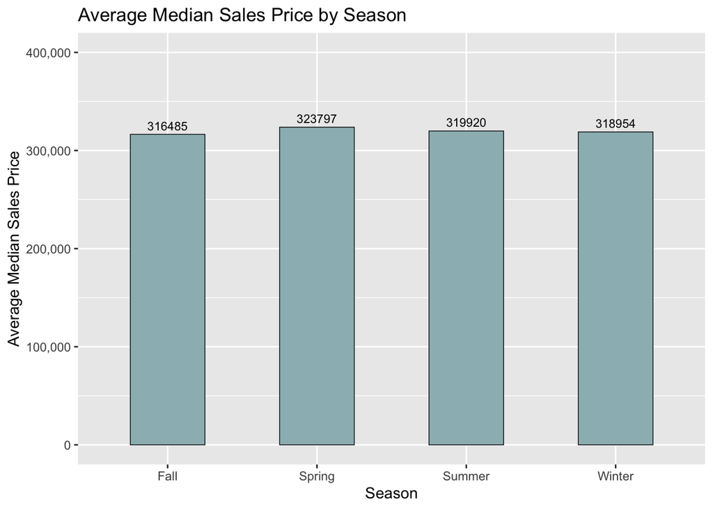

*Bar Chart Analysis:* The bar chart above displays the average median selling price of houses across all years of our data in each season. The visualization provides a quick snapshot of the differences in selling prices of homes by season, highlighting that on average, the selling price of houses in the spring is the highest, followed by summer, winter, and then fall. This is consistent with our hypothesis, as many buyers believe that houses have the most curb appeal in spring, and therefore, will pay more for houses sold during this time period.

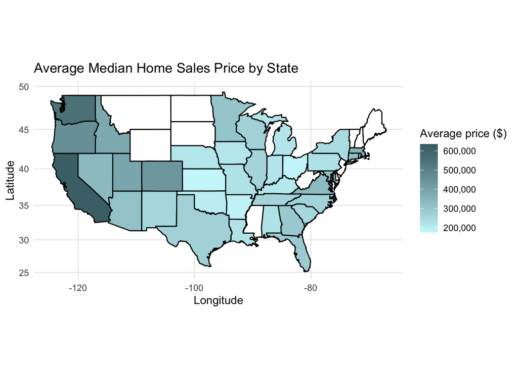

*Map Analysis:* The map above reflects the fact that the selling price of houses is not just dependent on the season, but on the location of the house as well. Darker shaded regions are those where houses sold for higher prices on average, while lighter shaded regions contain houses that sold for lower prices on average. The white states are states that we did not have data for. This visualization is helpful in capturing the effect of outside factors on selling price, displaying that there are likely many influences other than just season on selling price. Using the map visualization also provides useful information for future research projects.

## 6. T-tests

**T-test: Fall and Winter**

[output not shown]

*T-test Analysis: Fall to Winter:* The above statistics display the results from a t-test comparing the means of the median selling prices for homes in fall and winter. We chose to compare these two groups because they have the two lowest average median sales prices, as seen in our bar chart. The p-value is very high, 0.702, indicating that we fail to reject the null hypothesis - we cannot be certain that the difference between the means of the median selling prices of homes in fall and winter is different from zero. This suggests that seasonal differences in selling price, at least between fall and winter, are not substantial.

**T-test: Spring and Summer**

| T-statistic | Degrees of Freedom | P-value | 95% Confidence Interval |
| --- | --- | --- | --- |
| 0.554 | 2522.7 | 0.58 | -9847.142 - 17601.488 |

*T-test Analysis: Spring to Summer:* The above statistics display the results from a t-test comparing the means of the median selling prices for homes in spring and summer. We chose to compare these two groups because they have the two highest average median sales prices, as seen in our bar chart. As with the fall to winter comparison, the p-value is high, 0.5797, indicating that we fail to reject the null hypothesis: we cannot be certain that the difference between the means of the median selling prices of homes in spring and summer is different from zero. This p-value is lower than the winter to fall comparison, suggesting that seasonal differences in selling price are more substantial across spring and summer, but are still not statistically significant.